# Replication Study: Schlueter et al. (2019)

December 1, 2020

## Schlueter et al. (2019): Overview

- Processing
- Agreement attraction
- ‘The key to the cabinets **were** rusty.’
- Why don’t these sentences incur processing difficulty?
- Facilitation in memory architecture based on cue-based retrieval
- Highly debated topic in the psycholinguistics literature (Wagers et al. 2009, Dillon et al. 2013)

## Schlueter et al. (2019): Background

- Wagers et al. (2009): agreement attraction effect reflects an **error-triggered** cue-based retrieval mechanism
- Rechecking triggered by encountering agreement error on the verb
- Effect occurs when the attractor’s activation level in memory is higher than the subject’s

## Schlueter et al. (2019): Questions

- What is the structural representation of the input?
- Recall that final representations are not always consistent with the input (garden paths, implausible sentences)
- Is the attractor being reanalyzed as the subject?

## Schlueter et al. (2019): Questions

- Structural reanalysis or low-level rechecking?
- Reanalysis would mean excluding some of the input from the representation
- Rechecking would mean the final representation contains an agreement violation

## Schlueter et al. (2019): Methodology

- Is the attractor re-interpreted as the thematic subject?
- Self-paced reading with forced choice task
- 48 targets + 48 fillers
- 64 participants
- Factorial design: attractor number (sg, pl) x verb agreement (sg, pl)
- ex: ’The bed by the lamp was/were undoubtedly quite: comfortable / bright
- Choice of head-matching adjective → rechecking
- Choice of attractor-matching adjective → reanalysis

## Schlueter et al. (2019): Predictions

- No Restructring: grammatical subject = thematic subject
  - expect head-matching adjective choice
  - RT facilitation @*plural ungrammatical*: attractor = head-matching adj.
- Restructuring: attractor = thematic subject
  - more likely to choose attractor-matching adjective
  - RT facilitation @*plural ungrammatical*: attractor > head-matching adj.

## Schlueter et al. (2019): Results

- Participants chose the attractor-matching adjective more often in the *ungrammatical plural* condition, but still very infrequently
- ex: ‘The glass behind the curtains **were** most definitely: tattered / shattered’ → **tattered**
- RT data showed agreement attraction effect even when the head-matching adjective was chosen
- Results suggest that structural reanalysis only happens rarely

## Schlueter et al. (2019): RT

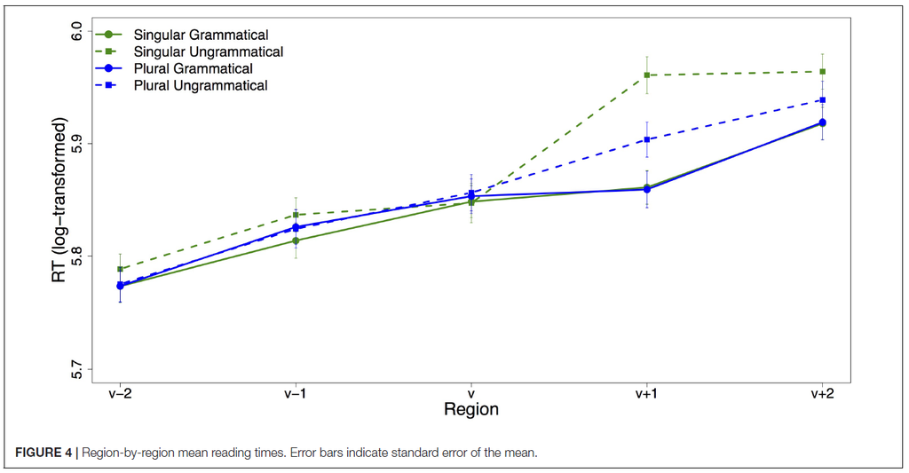

## Schlueter et al. (2019): head-matching adj. RT

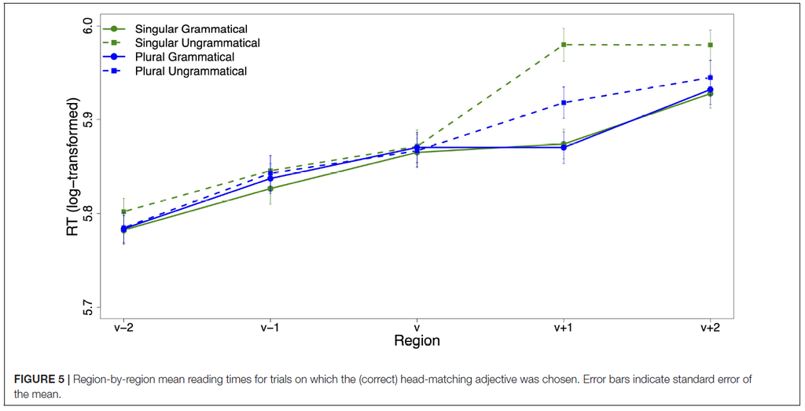

## Schlueter et al. (2019): attractor-matching adj. RT

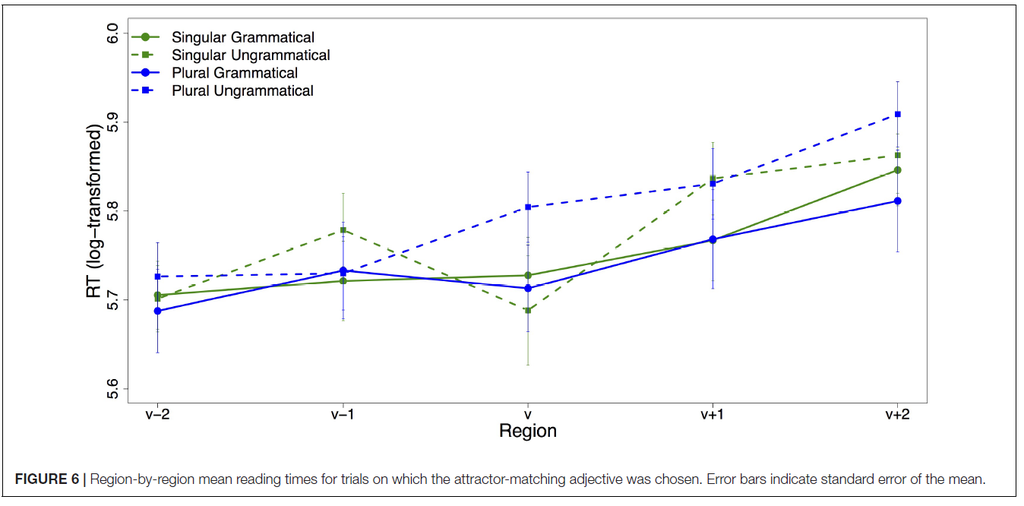

## Replication Study

- Platform: Ibex Farm
- 17 participants
- 48 experimental items (from Schueter et al.) + 48 fillers
- self-paced reading task + forced choice sentence completion
- Full procedure took approximately 10 minutes

Ex:

- Target: ’The glass behind the curtains were/was most definitely: tattered / shattered
- Filler: The child was usually fairly: sleepy / mountainous

## Data Summary

### Adjective choice accuracy

| condition | stim_type | grammaticality | attractor | n | n_correct | accuracy | stdev |
| --- | --- | --- | --- | --- | --- | --- | --- |
| filler | filler | NA | NA | 816 | 812 | 99.51% | 0.0699 |
| grammatical_pl | target | grammatical | plural | 204 | 187 | 91.67% | 0.2771 |
| grammatical_sg | target | grammatical | singular | 204 | 193 | 94.61% | 0.2264 |
| ungrammatical_pl | target | ungrammatical | plural | 204 | 185 | 90.69% | 0.2913 |
| ungrammatical_sg | target | ungrammatical | singular | 204 | 180 | 88.24% | 0.3230 |

## Data Summary

### Adjective choice accuracy: fillers vs. targets

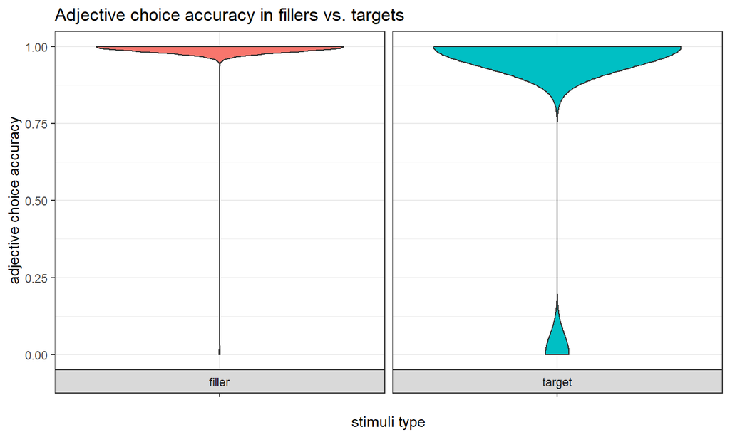

## Data Summary

### Adjective choice accuracy by condition

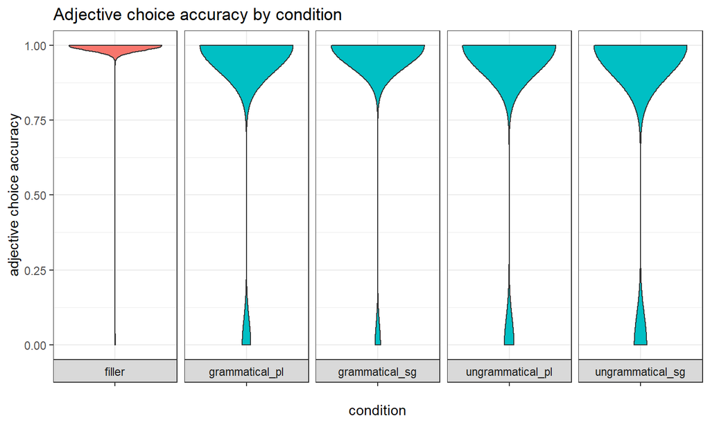

## Data Summary

### Adjective choice accuracy by condition

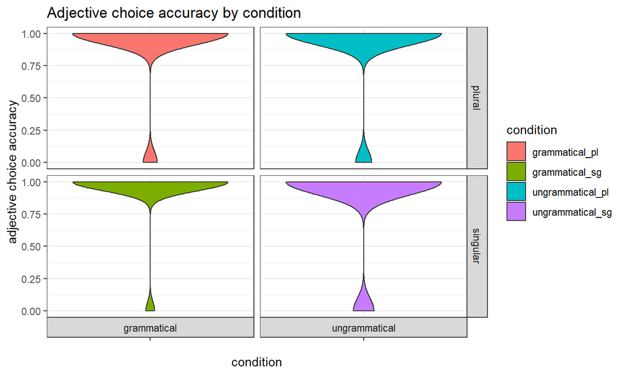

## Data Summary

### Adjective choice accuracy by condition

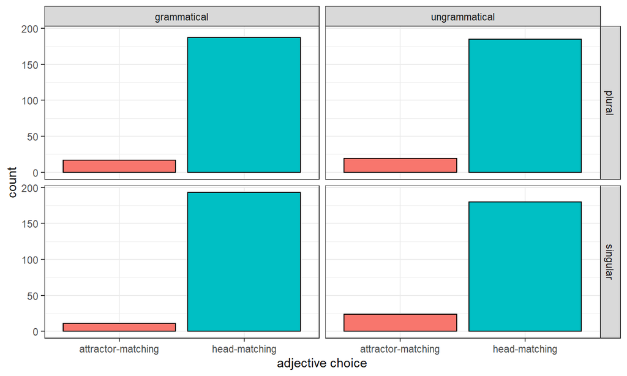

## Data Summary

### Verb RTs

| condition | stim_type | grammaticality | attractor | n | mean_RT | stdev_RT | mean_logRT | stdev_logRT |
| --- | --- | --- | --- | --- | --- | --- | --- | --- |
| filler | filler | NA | NA | 816 | 400.81 | 232.36 | 5.86 | 0.50 |
| grammatical_pl | target | grammatical | plural | 201 | 442.10 | 287.25 | 5.94 | 0.53 |
| grammatical_sg | target | grammatical | singular | 198 | 418.70 | 276.86 | 5.90 | 0.50 |
| ungrammatical_pl | target | ungrammatical | plural | 199 | 552.01 | 673.12 | 5.99 | 0.77 |
| ungrammatical_sg | target | ungrammatical | singular | 201 | 495.33 | 402.81 | 5.98 | 0.64 |

## Data Summary

### Verb RTs by condition

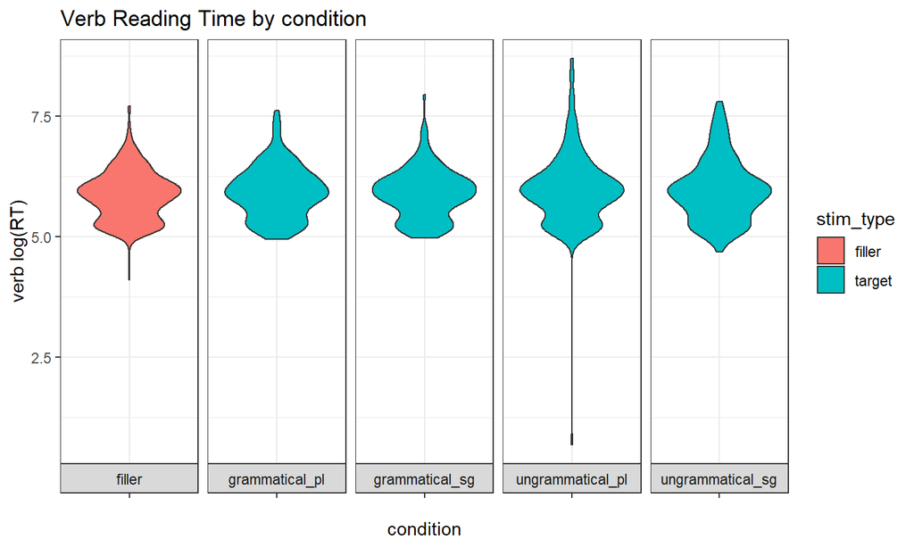

## Data Summary

### RTs by region

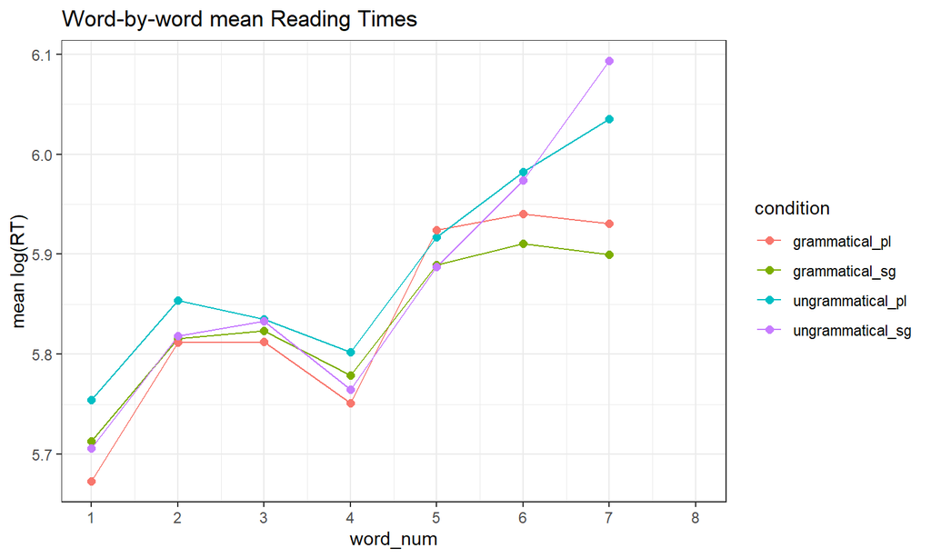

## Data Summary

### RTs by region: with variation

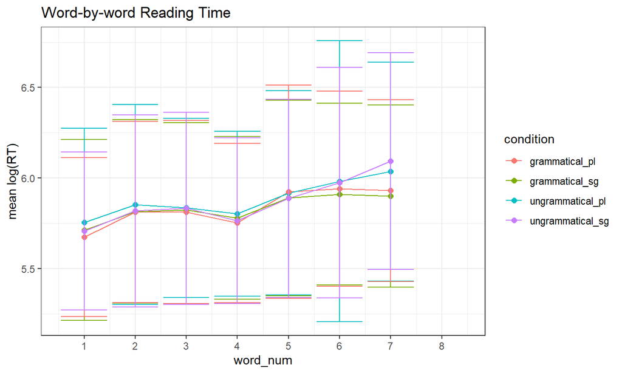

## Data Summary

### RT split by factors

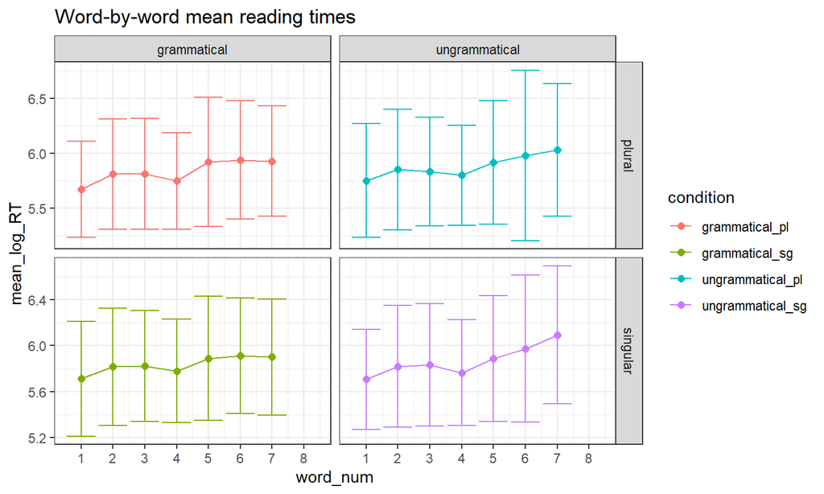

## Extra Data

### RTs by adjective choice

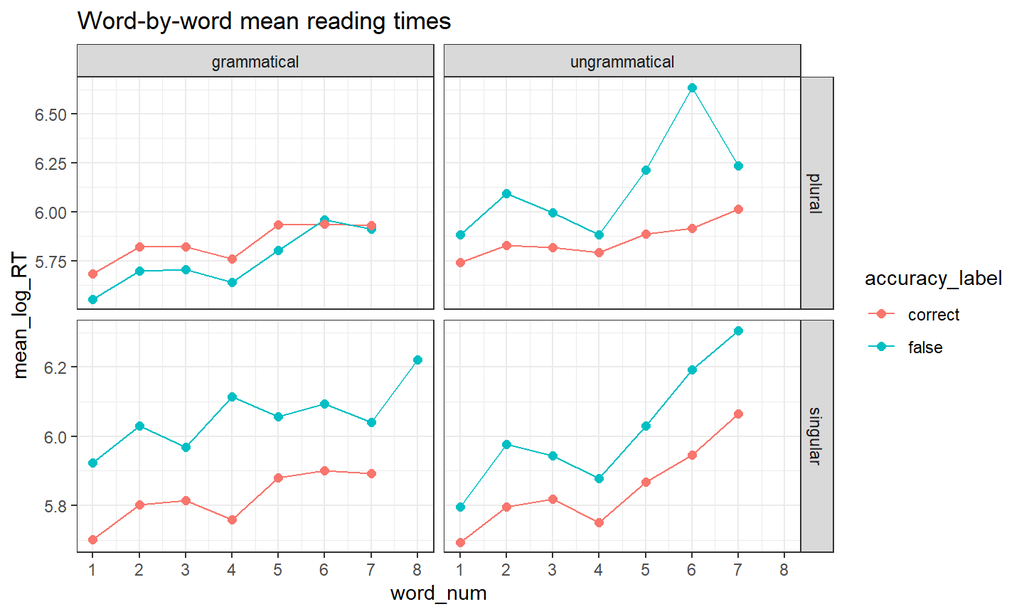

## Extra Data

### RTs by adjective choice with variation

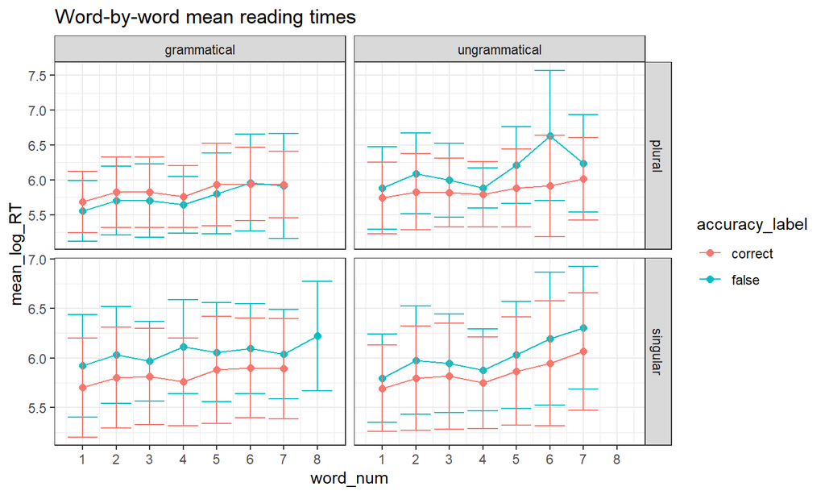

## Results: Overall

- Agreement attraction condition did not trigger more attractor-matching adjective choices
- Agreement attraction condition exhibited high RTs on the verb and spillover region, but also the most variation
- Inconclusive results overall

## Conclusion

- Thank you!
- Any questions?

## References

Dillon, B., Mishler, A., Sloggett, S., and Phillips, C. (2013). Contrasting intrusion profiles for agreement and anaphora: experimental and modeling evidence. *Journal of Memory and Language*, 36, 147.

Schlueter, Z., Parker, D., & Lau, E. (2019). Error-driven Retrieval in Agreement Attraction rarely leads to Misinterpretation. *Frontiers in psychology*, 10, 1002.

Wagers, M.W., Lau, E.F., and Phillips, C. (2009). Agreement attraction in comprehension: representations and processes. *Journal of Memory and Language*, 49, 285.